# COVID-19: First and Second Digits Analysis

## Plot of Daily Deaths by State

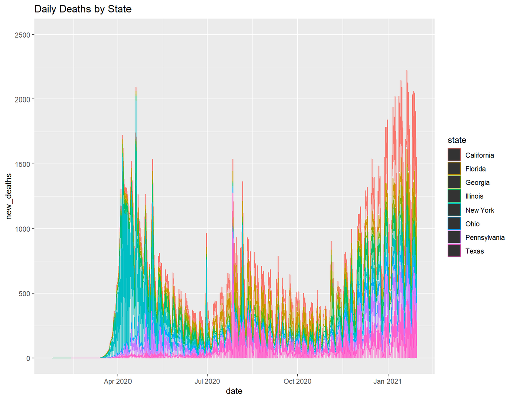

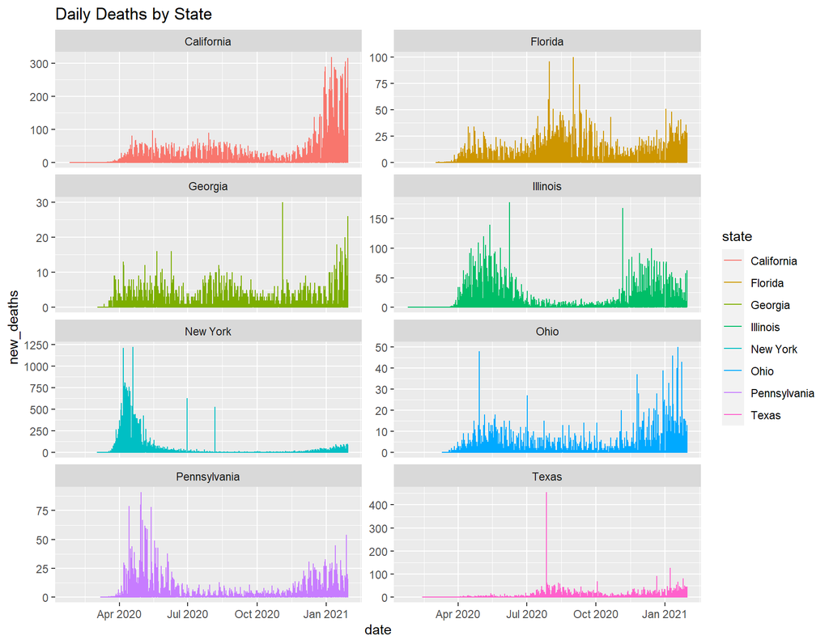

## Benford Analysis of Daily Cases by State

- Note: In general (daily) Cases match expected values better than (daily) Deaths

## New York State

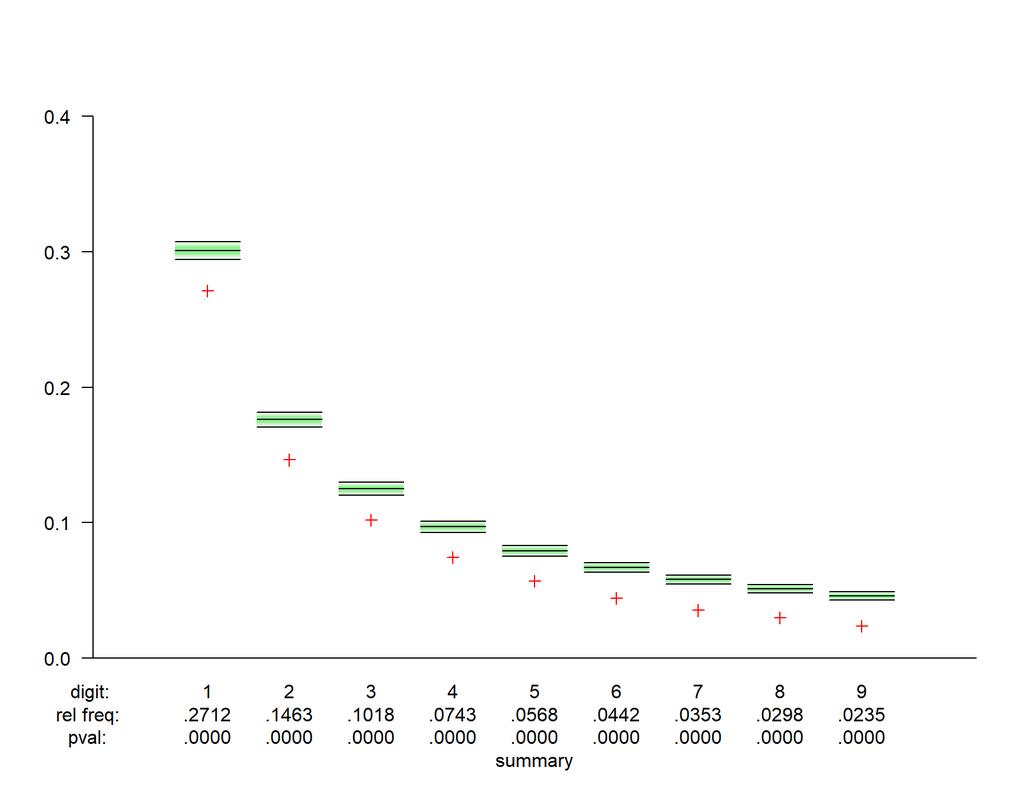

```
## $summary
##                  1            2            3            4            5
## freq  2.711883e-01 1.463032e-01 1.018443e-01 7.431446e-02 5.679052e-02
## pvals 9.072063e-19 2.073806e-26 2.156113e-21 2.884728e-25 1.738643e-29
##                  6            7            8            9
## freq  4.418844e-02 3.526421e-02 2.980150e-02 2.347342e-02
## pvals 3.284090e-35 6.537757e-40 1.177436e-39 1.198125e-47
##
## $CIs
##               1         2         3          4          5          6          7
## 0.025 0.2944181 0.1706009 0.1201727 0.09264578 0.07528910 0.06334424 0.05462294
## 0.5   0.3010300 0.1760913 0.1249387 0.09691001 0.07918125 0.06694679 0.05799195
## 0.975 0.3076419 0.1815816 0.1297048 0.10117425 0.08307340 0.07054934 0.06136096
##                8          9
## 0.025 0.04797694 0.04274551
## 0.5   0.05115252 0.04575749
## 0.975 0.05432810 0.04876947
```

#### Mean Absolute Deviation (MAD)

```
## [1] 0.009382362
```

## California

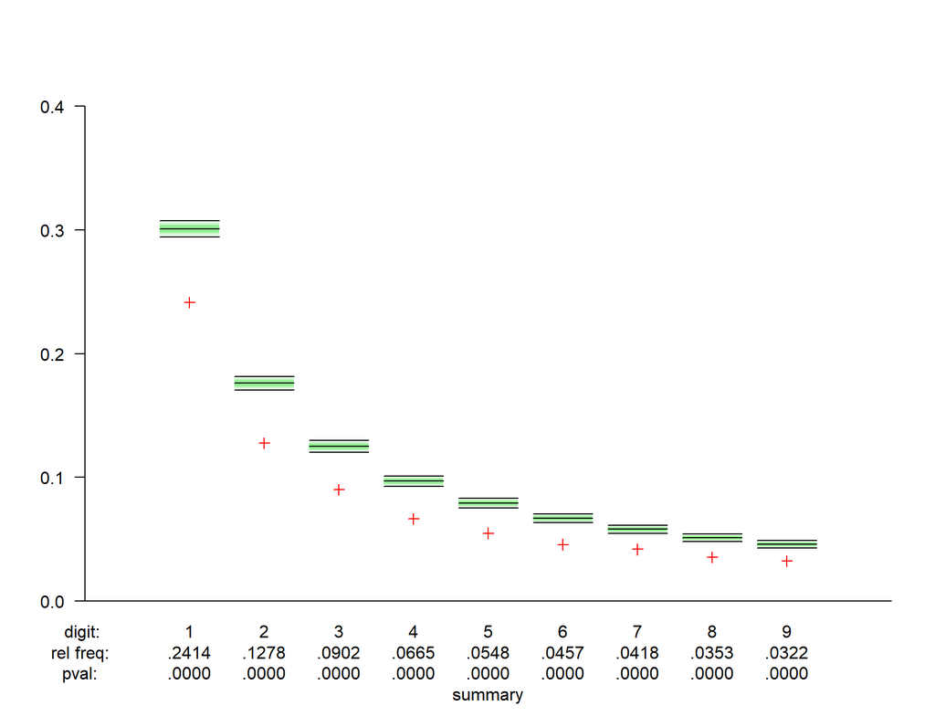

```
## $summary
##                  1            2            3            4            5
## freq  2.413700e-01 1.278000e-01 9.019587e-02 6.649713e-02 5.481009e-02
## pvals 5.803429e-70 1.427744e-66 2.724174e-46 2.184921e-44 1.308926e-34
##                  6            7            8            9
## freq  4.566605e-02 4.177037e-02 3.527757e-02 3.224759e-02
## pvals 5.479452e-31 3.898238e-21 1.169632e-22 1.501753e-18
##
## $CIs
##               1         2         3          4          5          6          7
## 0.025 0.2944169 0.1705999 0.1201718 0.09264497 0.07528836 0.06334356 0.05462230
## 0.5   0.3010300 0.1760913 0.1249387 0.09691001 0.07918125 0.06694679 0.05799195
## 0.975 0.3076431 0.1815826 0.1297057 0.10117506 0.08307413 0.07055002 0.06136160
##                8          9
## 0.025 0.04797634 0.04274494
## 0.5   0.05115252 0.04575749
## 0.975 0.05432870 0.04877004
```

- Mean Absolute Deviation (MAD)

```
## [1] 0.005610766
```

## Texas

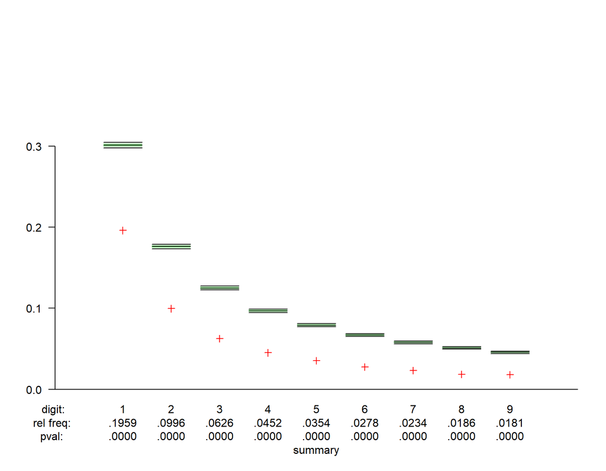

```
## $summary
##               1          2          3          4         5          6
## freq  0.1959471 0.09956029 0.06262186 0.04516788 0.0353786 0.02775425
## pvals 0.0000000 0.00000000 0.00000000 0.00000000 0.0000000 0.00000000
##                7          8             9
## freq  0.02337058 0.01859696  1.809943e-02
## pvals 0.00000000 0.00000000 2.681385e-285
##
## $CIs
##               1         2         3          4          5          6          7
## 0.025 0.2977332 0.1733537 0.1225623 0.09478379 0.07724056 0.06515050 0.05631210
## 0.5   0.3010300 0.1760913 0.1249387 0.09691001 0.07918125 0.06694679 0.05799195
## 0.975 0.3043268 0.1788288 0.1273152 0.09903623 0.08112194 0.06874308 0.05967179
##                8          9
## 0.025 0.04956913 0.04425567
## 0.5   0.05115252 0.04575749
## 0.975 0.05273592 0.04725931
```

- Mean Absolute Deviation (MAD)

```
## [1] 0.01107929
```

## Florida

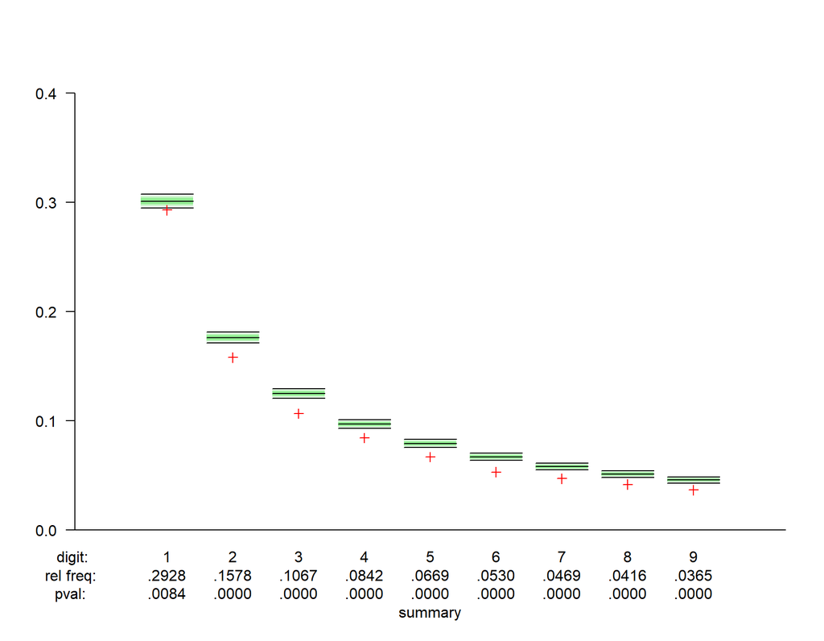

```
## $summary
##                 1            2            3            4            5
## freq  0.292780624 1.578482e-01 1.066605e-01 8.421053e-02 6.688402e-02
## pvals 0.008410403 2.252536e-12 5.497142e-16 3.174155e-10 2.505303e-11
##                  6            7            8            9
## freq  5.300419e-02 4.694923e-02 4.163950e-02 3.651607e-02
## pvals 2.980039e-16 4.428542e-12 2.498527e-10 9.154752e-11
##
## $CIs
##               1         2         3          4          5          6          7
## 0.025 0.2948943 0.1709963 0.1205159 0.09295287 0.07556939 0.06360368 0.05486556
## 0.5   0.3010300 0.1760913 0.1249387 0.09691001 0.07918125 0.06694679 0.05799195
## 0.975 0.3071657 0.1811862 0.1293616 0.10086716 0.08279310 0.07028990 0.06111834
##                8          9
## 0.025 0.04820563 0.04296242
## 0.5   0.05115252 0.04575749
## 0.975 0.05409941 0.04855256
```

[output not shown]

- Mean Absolute Deviation (MAD)

```
## [1] 0.007021101
```

## Illinois

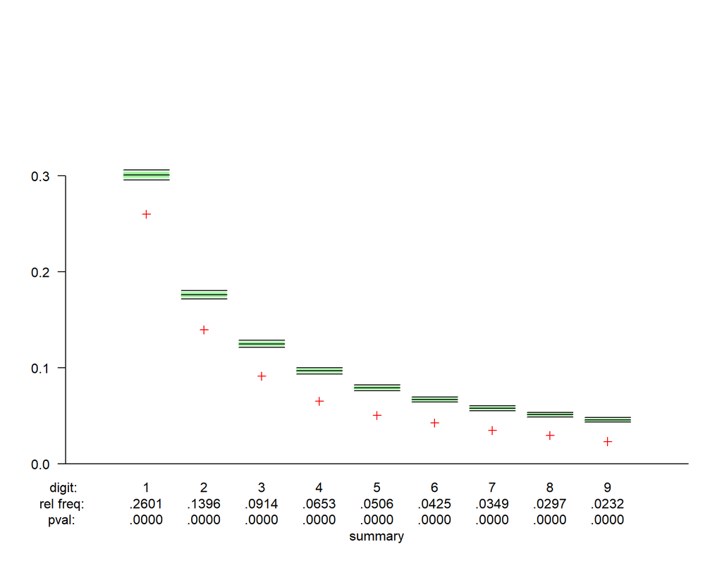

```
## $summary
##                  1            2            3            4            5
## freq  2.600737e-01 1.396378e-01 9.139285e-02 6.526687e-02 5.055297e-02
## pvals 5.013618e-56 4.249309e-64 8.380910e-72 1.333417e-79 3.052969e-78
##                  6            7            8            9
## freq  4.253887e-02 3.490944e-02 2.968424e-02 2.320885e-02
## pvals 1.145372e-66 3.909868e-68 2.193253e-66 5.521471e-81
##
## $CIs
##               1         2         3          4          5          6          7
## 0.025 0.2959397 0.1718644 0.1212695 0.09362713 0.07618482 0.06417332 0.05539826
## 0.5   0.3010300 0.1760913 0.1249387 0.09691001 0.07918125 0.06694679 0.05799195
## 0.975 0.3061203 0.1803181 0.1286080 0.10019290 0.08217767 0.06972026 0.06058563
##                8          9
## 0.025 0.04870776 0.04343868
## 0.5   0.05115252 0.04575749
## 0.975 0.05359729 0.04807631
```

- Mean Absolute Deviation (MAD)

[output not shown]

## Pennsylvania

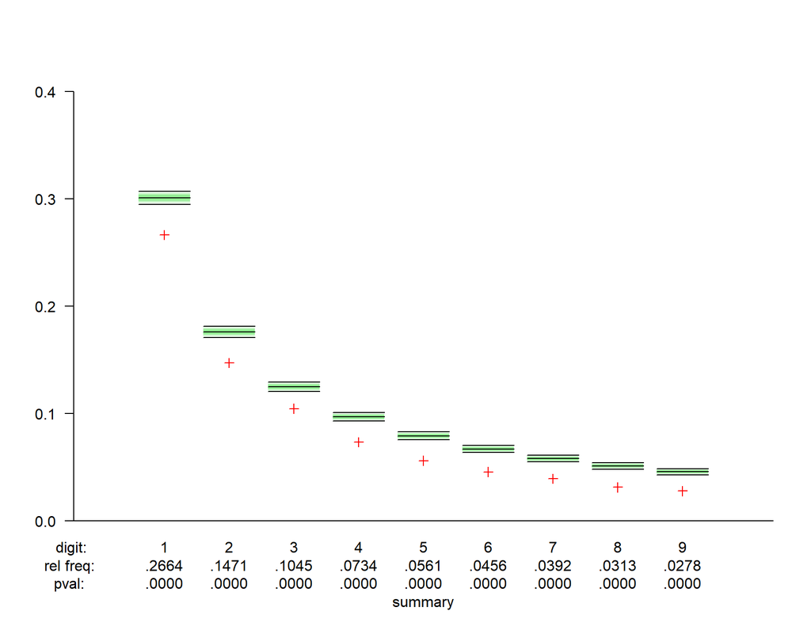

```
## $summary
##                  1            2            3            4            5
## freq  2.663558e-01 1.470714e-01 1.045344e-01 7.341676e-02 5.609744e-02
## pvals 6.038587e-28 2.313604e-28 3.678662e-19 1.138034e-30 2.833515e-35
##                  6            7            8            9
## freq  4.558215e-02 3.920636e-02 3.126041e-02 2.778703e-02
## pvals 2.865510e-35 2.242362e-31 3.763645e-39 1.121031e-35
##
## $CIs
##               1         2         3          4          5          6          7
## 0.025 0.2948285 0.1709417 0.1204685 0.09291045 0.07553067 0.06356785 0.05483204
## 0.5   0.3010300 0.1760913 0.1249387 0.09691001 0.07918125 0.06694679 0.05799195
## 0.975 0.3072315 0.1812408 0.1294090 0.10090958 0.08283182 0.07032573 0.06115185
##                8          9
## 0.025 0.04817404 0.04293246
## 0.5   0.05115252 0.04575749
## 0.975 0.05413100 0.04858252
```

- Mean Absolute Deviation (MAD)

```
## [1] 0.008411703
```

## Ohio

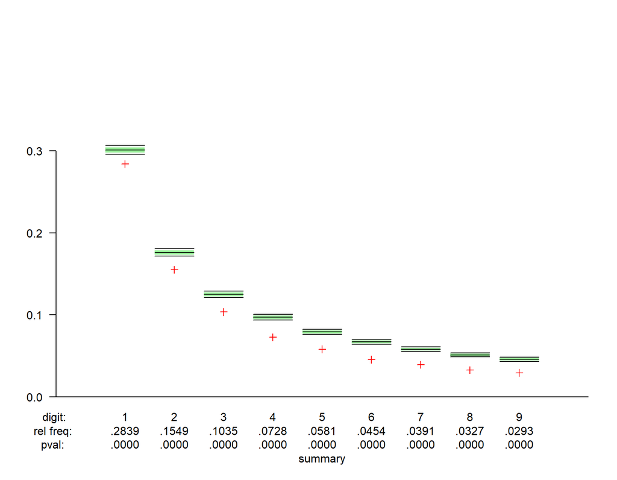

```
## $summary
##                  1            2            3            4            5
## freq  2.839046e-01 1.549301e-01 1.034571e-01 7.279232e-02 5.811704e-02
## pvals 6.446900e-10 3.750512e-20 5.751938e-27 1.721604e-41 3.891734e-38
##                  6            7            8            9
## freq  4.544957e-02 3.906107e-02 3.267258e-02 2.931406e-02
## pvals 5.487449e-46 5.623081e-41 8.011967e-44 8.910457e-39
##
## $CIs
##              1         2         3          4          5          6          7
## 0.025 0.295598 0.1715806 0.1210232 0.09340671 0.07598363 0.06398710 0.05522412
## 0.5   0.301030 0.1760913 0.1249387 0.09691001 0.07918125 0.06694679 0.05799195
## 0.975 0.306462 0.1806019 0.1288543 0.10041332 0.08237886 0.06990648 0.06075978
##                8          9
## 0.025 0.04854361 0.04328298
## 0.5   0.05115252 0.04575749
## 0.975 0.05376144 0.04823200
```

- Mean Absolute Deviation (MAD)

```
## [1] 0.009274283
```

## California

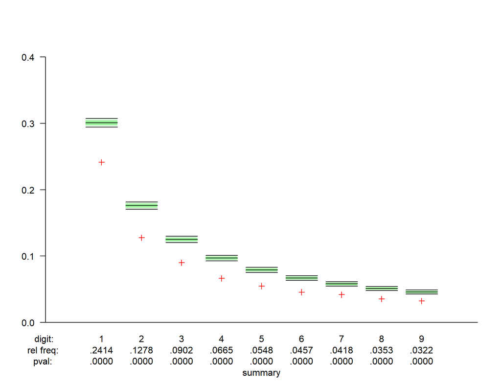

```
## $summary
##                  1            2            3            4            5
## freq  2.413700e-01 1.278000e-01 9.019587e-02 6.649713e-02 5.481009e-02
## pvals 5.803429e-70 1.427744e-66 2.724174e-46 2.184921e-44 1.308926e-34
##                  6            7            8            9
## freq  4.566605e-02 4.177037e-02 3.527757e-02 3.224759e-02
## pvals 5.479452e-31 3.898238e-21 1.169632e-22 1.501753e-18
##
## $CIs
##               1         2         3          4          5          6          7
## 0.025 0.2944169 0.1705999 0.1201718 0.09264497 0.07528836 0.06334356 0.05462230
## 0.5   0.3010300 0.1760913 0.1249387 0.09691001 0.07918125 0.06694679 0.05799195
## 0.975 0.3076431 0.1815826 0.1297057 0.10117506 0.08307413 0.07055002 0.06136160
##                8          9
## 0.025 0.04797634 0.04274494
## 0.5   0.05115252 0.04575749
## 0.975 0.05432870 0.04877004
```

- Mean Absolute Deviation (MAD)

```
## [1] 0.005610766
```

## Georgia

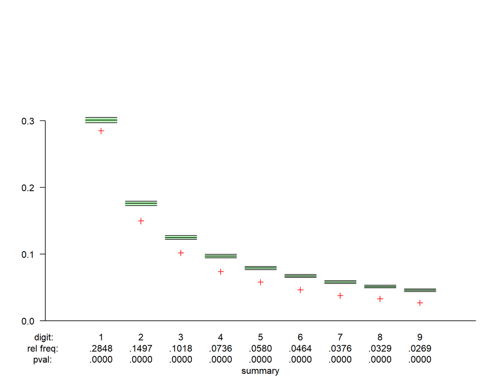

```
## $summary
##                  1            2            3            4            5
## freq  2.848202e-01 1.496519e-01 1.017673e-01 7.356216e-02 5.795502e-02
## pvals 3.023730e-15 3.590070e-54 3.518960e-55 1.706054e-69 5.840804e-69
##                  6            7            8            9
## freq  4.638007e-02 3.755341e-02 3.289936e-02 2.688118e-02
## pvals 2.169488e-75 6.876554e-85 2.126041e-76 1.832274e-90
##
## $CIs
##               1         2         3          4          5          6          7
## 0.025 0.2970033 0.1727476 0.1220361 0.09431303 0.07681087 0.06475278 0.05594017
## 0.5   0.3010300 0.1760913 0.1249387 0.09691001 0.07918125 0.06694679 0.05799195
## 0.975 0.3050567 0.1794350 0.1278413 0.09950700 0.08155163 0.06914080 0.06004373
##                8          9
## 0.025 0.04921854 0.04392315
## 0.5   0.05115252 0.04575749
## 0.975 0.05308650 0.04759183
```

- Mean Absolute Deviation (MAD)

```
## [1] 0.01204187
```

## Benford Analysis of Daily Deaths by State

## New York State

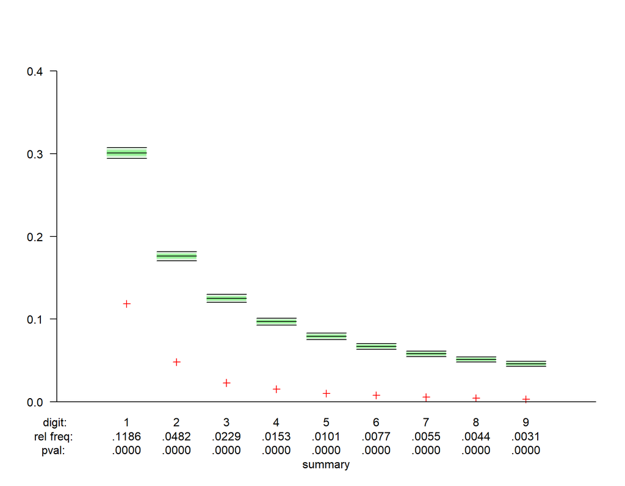

```
## $summary
##               1          2          3          4             5             6
## freq  0.1186111 0.04819082 0.02287847 0.01525231  1.006004e-02  7.734329e-03
## pvals 0.0000000 0.00000000 0.00000000 0.00000000 1.888974e-265 1.104968e-227
##                   7             8             9
## freq   5.516794e-03  4.435070e-03  3.082914e-03
## pvals 1.105705e-204 8.054245e-183 1.018094e-169
##
## $CIs
##               1         2         3          4          5          6          7
## 0.025 0.2944181 0.1706009 0.1201727 0.09264578 0.07528910 0.06334424 0.05462294
## 0.5   0.3010300 0.1760913 0.1249387 0.09691001 0.07918125 0.06694679 0.05799195
## 0.975 0.3076419 0.1815816 0.1297048 0.10117425 0.08307340 0.07054934 0.06136096
##                8          9
## 0.025 0.04797694 0.04274551
## 0.5   0.05115252 0.04575749
## 0.975 0.05432810 0.04876947
```

#### Mean Absolute Deviation (MAD)

```
## [1] 0.01708036
```

## California

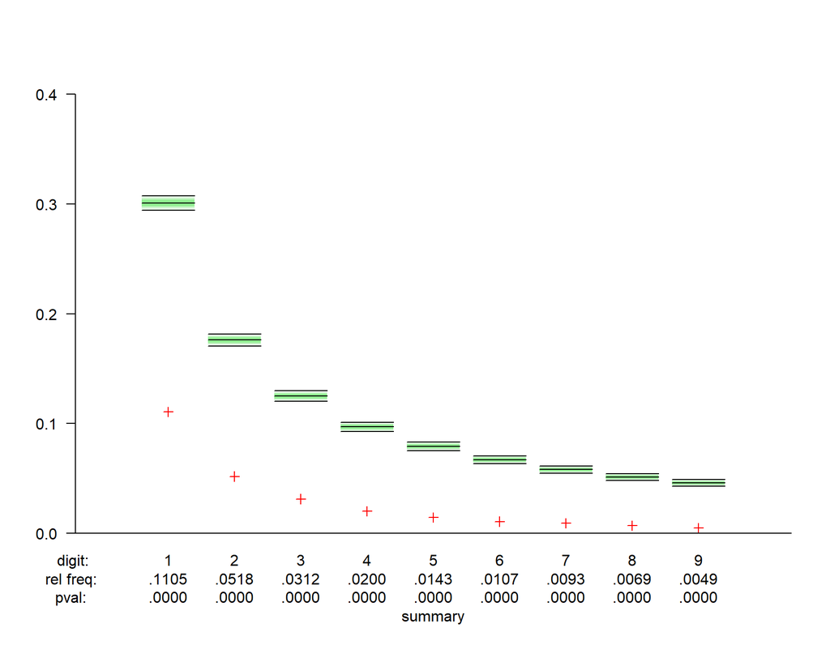

```
## $summary
##             1          2          3             4             5             6
## freq  0.11054 0.05178011 0.03121956  2.001948e-02  1.428417e-02  1.065902e-02
## pvals 0.00000 0.00000000 0.00000000 1.741834e-273 3.664689e-234 7.148489e-206
##                   7             8             9
## freq   9.252245e-03  6.925657e-03  4.869603e-03
## pvals 8.477175e-177 5.337113e-164 6.495054e-156
##
## $CIs
##               1         2         3          4          5          6          7
## 0.025 0.2944169 0.1705999 0.1201718 0.09264497 0.07528836 0.06334356 0.05462230
## 0.5   0.3010300 0.1760913 0.1249387 0.09691001 0.07918125 0.06694679 0.05799195
## 0.975 0.3076431 0.1815826 0.1297057 0.10117506 0.08307413 0.07055002 0.06136160
##                8          9
## 0.025 0.04797634 0.04274494
## 0.5   0.05115252 0.04575749
## 0.975 0.05432870 0.04877004
```

- Mean Absolute Deviation (MAD)

```
## [1] 0.01598147
```

## Texas

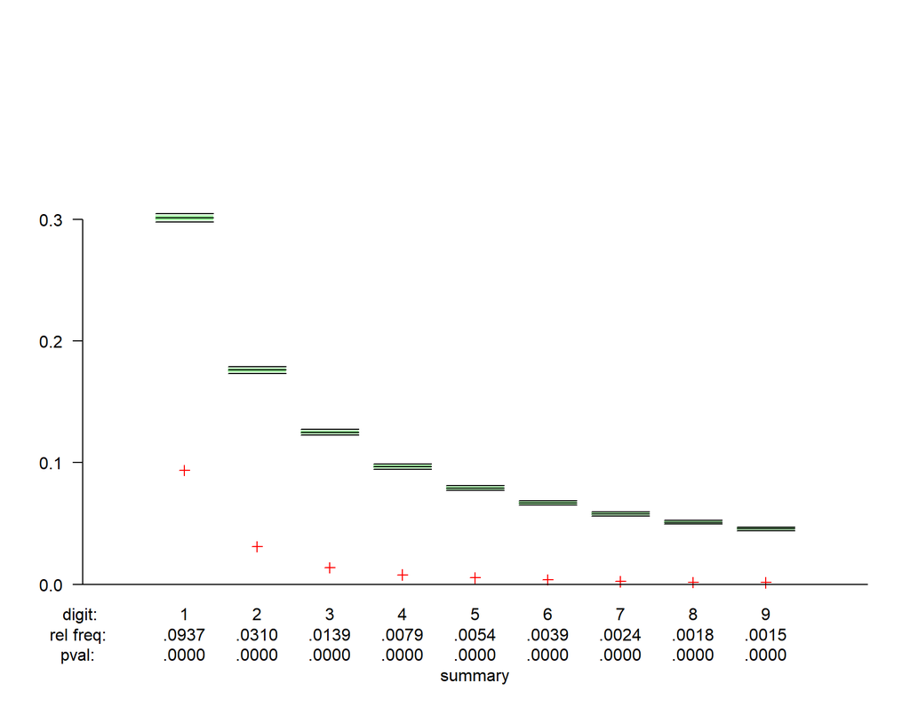

```
## $summary
##                1          2          3           4           5           6
## freq  0.09372437 0.03104872 0.01393091 0.007933626 0.005405623 0.003913026
## pvals 0.00000000 0.00000000 0.00000000 0.000000000 0.000000000 0.000000000
##                 7           8           9
## freq  0.002433875 0.001828768 0.001532938
## pvals 0.000000000 0.000000000 0.000000000
##
## $CIs
##               1         2         3          4          5          6          7
## 0.025 0.2977332 0.1733537 0.1225623 0.09478379 0.07724056 0.06515050 0.05631210
## 0.5   0.3010300 0.1760913 0.1249387 0.09691001 0.07918125 0.06694679 0.05799195
## 0.975 0.3043268 0.1788288 0.1273152 0.09903623 0.08112194 0.06874308 0.05967179
##                8          9
## 0.025 0.04956913 0.04425567
## 0.5   0.05115252 0.04575749
## 0.975 0.05273592 0.04725931
```

- Mean Absolute Deviation (MAD)

```
## [1] 0.01851941
```

## Florida

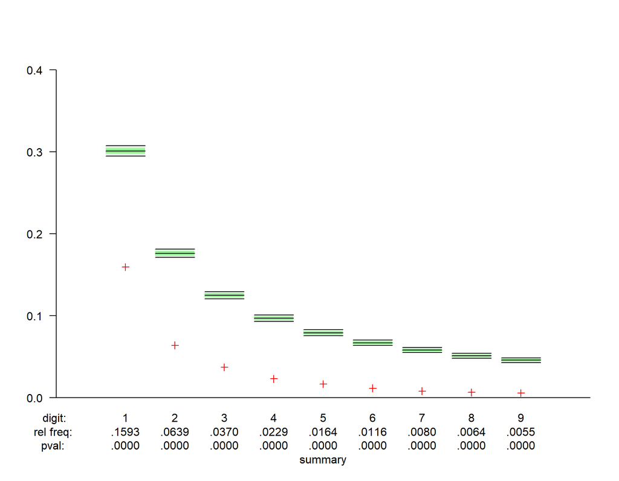

```
## $summary
##               1          2          3             4             5             6
## freq  0.1593386 0.06390312 0.03702841  2.291570e-02  1.644155e-02  1.155100e-02
## pvals 0.0000000 0.00000000 0.00000000 4.711533e-294 4.725152e-254 2.259377e-231
##                   7             8             9
## freq   8.011178e-03  6.380997e-03  5.542618e-03
## pvals 1.636727e-215 7.674142e-195 5.921614e-175
##
## $CIs
##               1         2         3          4          5          6          7
## 0.025 0.2948943 0.1709963 0.1205159 0.09295287 0.07556939 0.06360368 0.05486556
## 0.5   0.3010300 0.1760913 0.1249387 0.09691001 0.07918125 0.06694679 0.05799195
## 0.975 0.3071657 0.1811862 0.1293616 0.10086716 0.08279310 0.07028990 0.06111834
##                8          9
## 0.025 0.04820563 0.04296242
## 0.5   0.05115252 0.04575749
## 0.975 0.05409941 0.04855256
```

[output not shown]

- Mean Absolute Deviation (MAD)

```
## [1] 0.01794218
```

## Illinois

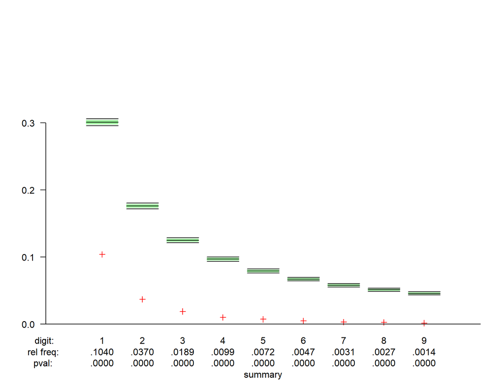

```
## $summary
##               1          2          3           4           5          6
## freq  0.1040231 0.03699311 0.01888123 0.009905434 0.007212694 0.00474435
## pvals 0.0000000 0.00000000 0.00000000 0.000000000 0.000000000 0.00000000
##                 7           8             9
## freq  0.003109473 0.002724796  1.442539e-03
## pvals 0.000000000 0.000000000 4.630891e-307
##
## $CIs
##               1         2         3          4          5          6          7
## 0.025 0.2959397 0.1718644 0.1212695 0.09362713 0.07618482 0.06417332 0.05539826
## 0.5   0.3010300 0.1760913 0.1249387 0.09691001 0.07918125 0.06694679 0.05799195
## 0.975 0.3061203 0.1803181 0.1286080 0.10019290 0.08217767 0.06972026 0.06058563
##                8          9
## 0.025 0.04870776 0.04343868
## 0.5   0.05115252 0.04575749
## 0.975 0.05359729 0.04807631
```

- Mean Absolute Deviation (MAD)

[output not shown]

## Pennsylvania

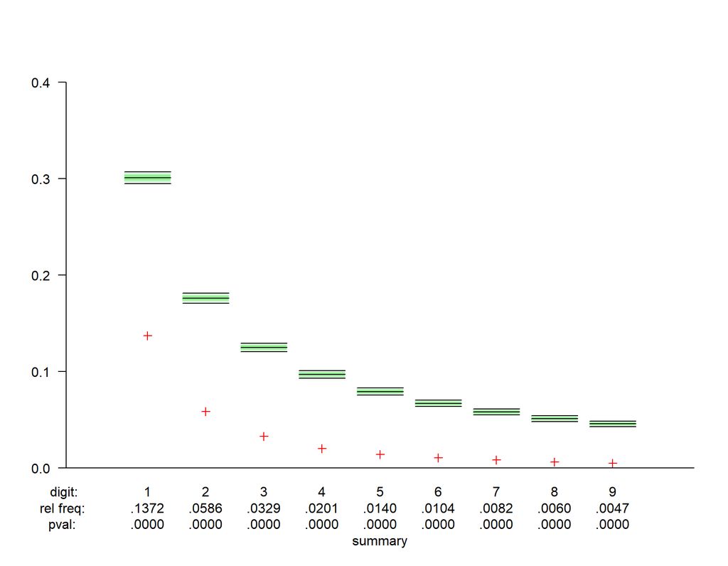

```
## $summary
##               1          2          3          4             5             6
## freq  0.1372222 0.05857163 0.03287815 0.02012656  1.398868e-02  1.037256e-02
## pvals 0.0000000 0.00000000 0.00000000 0.00000000 2.143324e-268 3.478946e-236
##                   7             8             9
## freq   8.231432e-03  5.995147e-03  4.662892e-03
## pvals 3.580588e-209 4.849650e-194 8.603387e-179
##
## $CIs
##               1         2         3          4          5          6          7
## 0.025 0.2948285 0.1709417 0.1204685 0.09291045 0.07553067 0.06356785 0.05483204
## 0.5   0.3010300 0.1760913 0.1249387 0.09691001 0.07918125 0.06694679 0.05799195
## 0.975 0.3072315 0.1812408 0.1294090 0.10090958 0.08283182 0.07032573 0.06115185
##                8          9
## 0.025 0.04817404 0.04293246
## 0.5   0.05115252 0.04575749
## 0.975 0.05413100 0.04858252
```

- Mean Absolute Deviation (MAD)

```
## [1] 0.01831264
```

## Ohio

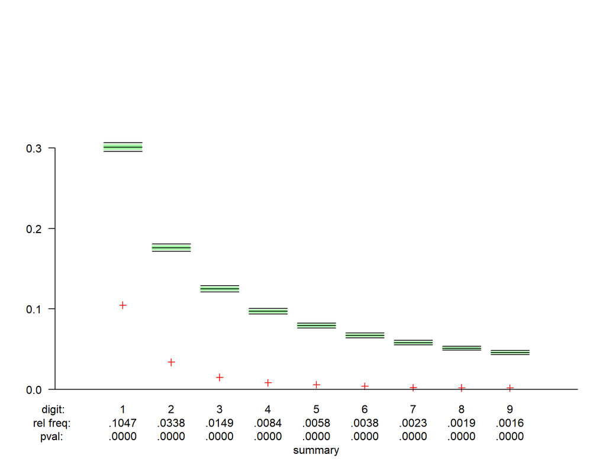

```
## $summary
##               1          2          3         4           5           6
## freq  0.1046618 0.03380426 0.01493082 0.0083598 0.005840908 0.003833096
## pvals 0.0000000 0.00000000 0.00000000 0.0000000 0.000000000 0.000000000
##                 7             8             9
## freq  0.002263352  1.898295e-03  1.606250e-03
## pvals 0.000000000 1.042189e-299 6.313283e-268
##
## $CIs
##              1         2         3          4          5          6          7
## 0.025 0.295598 0.1715806 0.1210232 0.09340671 0.07598363 0.06398710 0.05522412
## 0.5   0.301030 0.1760913 0.1249387 0.09691001 0.07918125 0.06694679 0.05799195
## 0.975 0.306462 0.1806019 0.1288543 0.10041332 0.08237886 0.06990648 0.06075978
##                8          9
## 0.025 0.04854361 0.04328298
## 0.5   0.05115252 0.04575749
## 0.975 0.05376144 0.04823200
```

- Mean Absolute Deviation (MAD)

```
## [1] 0.01908837
```

## California

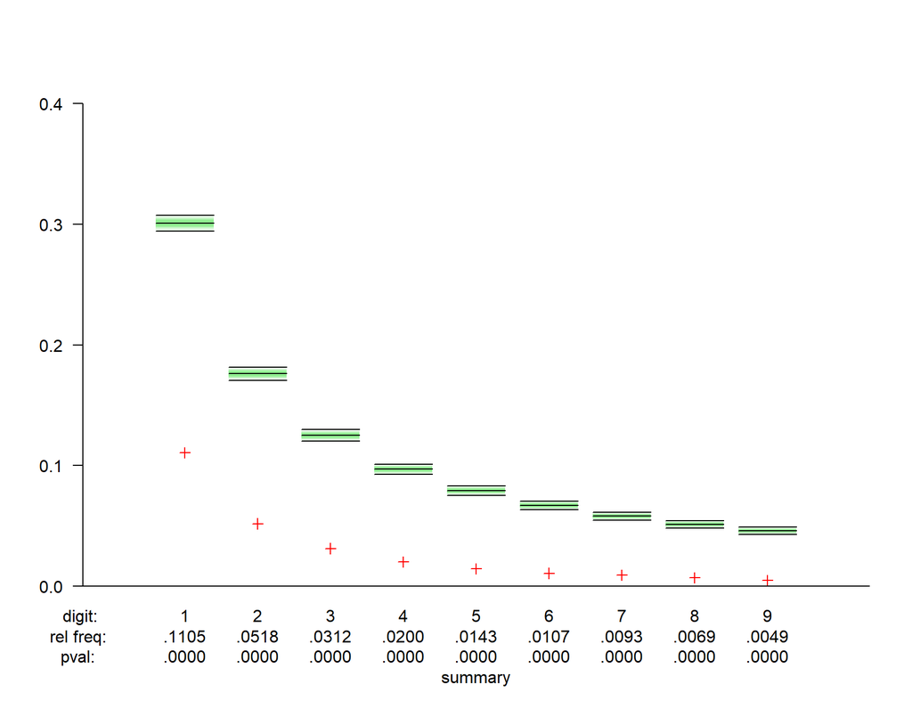

```
## $summary
##             1          2          3             4             5             6
## freq  0.11054 0.05178011 0.03121956  2.001948e-02  1.428417e-02  1.065902e-02
## pvals 0.00000 0.00000000 0.00000000 1.741834e-273 3.664689e-234 7.148489e-206
##                   7             8             9
## freq   9.252245e-03  6.925657e-03  4.869603e-03
## pvals 8.477175e-177 5.337113e-164 6.495054e-156
##
## $CIs
##               1         2         3          4          5          6          7
## 0.025 0.2944169 0.1705999 0.1201718 0.09264497 0.07528836 0.06334356 0.05462230
## 0.5   0.3010300 0.1760913 0.1249387 0.09691001 0.07918125 0.06694679 0.05799195
## 0.975 0.3076431 0.1815826 0.1297057 0.10117506 0.08307413 0.07055002 0.06136160
##                8          9
## 0.025 0.04797634 0.04274494
## 0.5   0.05115252 0.04575749
## 0.975 0.05432870 0.04877004
```

- Mean Absolute Deviation (MAD)

```
## [1] 0.01598147
```

## Georgia

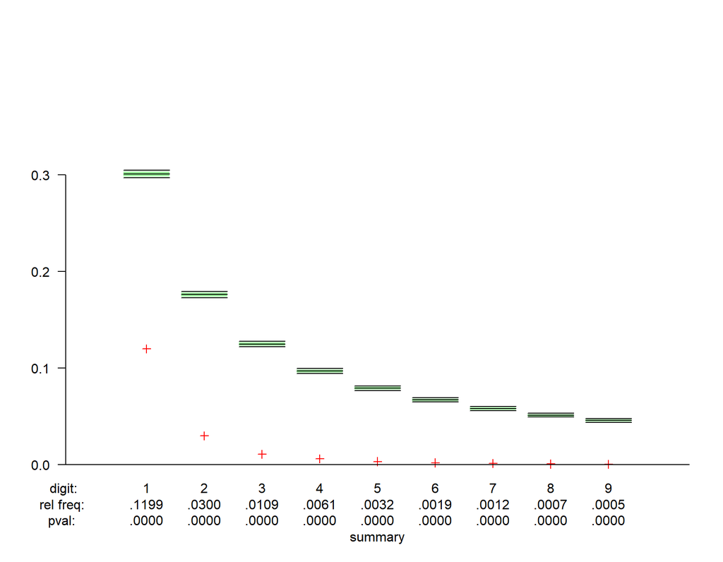

```
## $summary
##              1          2          3           4           5           6
## freq  0.119882 0.03001063 0.01087284 0.006058296 0.003189633 0.001925816
## pvals 0.000000 0.00000000 0.00000000 0.000000000 0.000000000 0.000000000
##                 7            8            9
## freq  0.001183574 0.0006820598 0.0004613934
## pvals 0.000000000 0.0000000000 0.0000000000
##
## $CIs
##               1         2         3          4          5          6          7
## 0.025 0.2970033 0.1727476 0.1220361 0.09431303 0.07681087 0.06475278 0.05594017
## 0.5   0.3010300 0.1760913 0.1249387 0.09691001 0.07918125 0.06694679 0.05799195
## 0.975 0.3050567 0.1794350 0.1278413 0.09950700 0.08155163 0.06914080 0.06004373
##                8          9
## 0.025 0.04921854 0.04392315
## 0.5   0.05115252 0.04575749
## 0.975 0.05308650 0.04759183
```

- Mean Absolute Deviation (MAD)

```
## [1] 0.01953847
```